# Exemplos de uso - Operação convolucional

código apresentado por Vasilev et al (2019), que exemplifica uma operação convolucional ao aplicar alguns filtros a uma imagem.

*Importação da biblioteca NumPy*

Numpy é uma biblioteca para manipulação de arrays multimendimensionais para processamento de cálculos matemáticos.

```python
import numpy as np
```

Em seguida, será definida a função conv, que aplicará a convolução pela imagem.

Essa função utiliza dois parâmetros: image para a imagem e filter para o filtro.

Esta etapa será realizada em quatro passos:

```
I. calcular do tamanho da imagem de saída, que depende do tamanho da imagem de entrada e do filtro, será chamado de im_c;

II. passar o filtro por toda a imagem;

III. verificar se algum valor gerado está fora do intervalo [0, 255], que é o intervalo de valores para tons de cinza em uma imagem, e caso algum valor esteja fora, corrigir;

IV. mostrar a imagem de entrada e a de saída para comparação
```

```python
def conv(image, im_filter):
    """
        :param image: grayscale image as a 2-dimensional numpy
        array
        :param im_filter: 2-dimensional numpy array
    """
    # Tamanho da Entrada
    height = image.shape[0]
    width = image.shape[1]

    # Imagem de saída com tamanho reduzido
    im_c = np.zeros((height - len(im_filter) + 1, width - len(im_filter) + 1))

    # Passando por todas as linhas e colunas
    for row in range(len(im_c)):
        for col in range(len(im_c[0])):
            # Aplicando o filtro
            for i in range(len(im_filter)):
                for j in range(len(im_filter[0])):
                    im_c[row, col] += image[row + i, col + j] * im_filter[i][j]

    # Corrigindo os valores for a do intervalo entre [0,255]
    im_c[im_c > 255] = 255
    im_c[im_c < 0] = 0

    # Mostrando as imagens para comparação
    import matplotlib.pyplot as plt
    import matplotlib.cm as cm
    plt.figure()
    plt.imshow(image, cmap=cm.Greys_r)
    plt.show()

    plt.imshow(im_c, cmap=cm.Greys_r)
    plt.show()
```

*Baixando a imagem em RGB solicitada para uma matriz numpy e a converte para tons de cinza.*

```python
import requests
from PIL import Image
from io import BytesIO

# Baixando a imagem
url = "https://upload.wikimedia.org/wikipedia/commons/thumb/8/88/Commander_Eileen_Collins_-_GPN-2000-001177.jpg/382px-Commander_Eileen_Collins_-_GPN-2000-001177.jpg?download"
resp = requests.get(url)
image_rgb = np.asarray(Image.open(BytesIO(resp.content)).convert("RGB"))

# Convertendo para tons de cinza
image_grayscale = np.mean(image_rgb, axis=2, dtype=np.uint)
```

*Aplicando filtros à imagem*

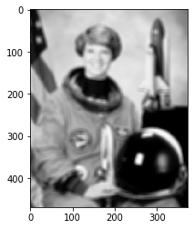

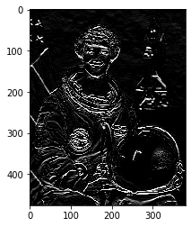

[figure not shown]

```python
# Filtro blur
blur = np.full([10, 10], 1. / 100)
conv(image_grayscale, blur)

# Sobel para detectar contornos
sobel_x = [[-1, -2, -1], [0, 0, 0], [1, 2, 1]]
conv(image_grayscale, sobel_x)

sobel_y = [[-1, 0, 1], [-2, 0, 2], [-1, 0, 1]]
conv(image_grayscale, sobel_y)
```

[output not shown]

Nem sempre os filtros passam por cada um dos pixels de uma imagem, eles podem pular alguns pixels, a esse parâmetro, dá-se o nome de passo, que deve ser constante por toda a imagem. Ao utilizar um passo maior do que 1 (quando o filtro passa por todos os neurônios) acontece a redução do tamanho do mapa de características gerado. Sendo assim, um mesmo neurônio da próxima camada será ativado por uma área maior da imagem de entrada, o que permite que características mais complexas sejam reconhecidas.

É comum gerar saídas menores que a entrada, porém, o ideal é que o tamanho das saídas seja compatível com o tamanho da entrada. Neste caso, é necessário preencher as bordas da imagem de entrada com zeros antes da operação de convolução.

**Deconvolução**

Da mesma forma que o Backpropagation funciona em uma rede neural totalmente conectada, ele funciona na convolução, ou seja, os mesmos neurônios determinarão os gradientes dos passos de volta ao fazer o backpropagation. Essa ação é conhecida como convolução transposta, ou deconvolução.

Algumas bibliotecas de Deep Learning como Pytorch, Keras e TensorFlow suportam os padrões 1D, 2D e 3D, e também, convoluções em escala profunda. Neste caso, tanto os operadores de entrada quanto os de saída são tensores.